# On Floating Points and Rounding Errors

[figure not shown]

[xkcd/217](https://xkcd.com/217/)

## [WAR IN THE GULF: Scud Attack; Scud Missile Hits a U.S. Barracks, Killing 27](https://www.nytimes.com/1991/02/26/world/war-in-the-gulf-scud-attack-scud-missile-hits-a-us-barracks-killing-27.html?)

Operation Desert Storm, Feb 25th, 1991, Dhahran, Saudi Arabia

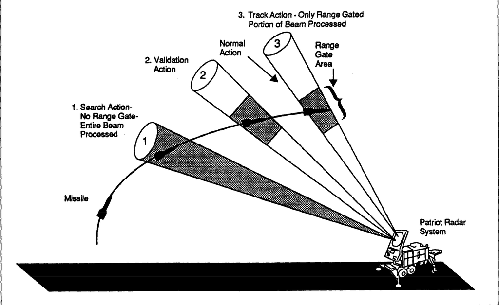

```python
Image(filename='./images/correct.png')
```

```python
infinite_one_tenth = '0.00011001100110011001100110011(0011)...'
one_tenth          = '0.00011001100110011001100'

def float_from_bstring(s):
    """s is string of the form 0.xxxxxx where x is a bit"""
    ans = 0
    for i, b in enumerate(s[2:], 1):
        ans += int(b)/2**i
    return ans

def to_seconds(counter):
    return float_from_bstring(one_tenth)*counter
```

```python
runtime = 100 # in hours
error = runtime * 3600 - to_seconds(runtime*3600*10)  # in seconds
error
```

```
0.34332275390625
```

```python
scud_velocity = 1676 # m/s
scud_travelled = error * scud_velocity  # in meters
scud_travelled
```

```
575.408935546875
```

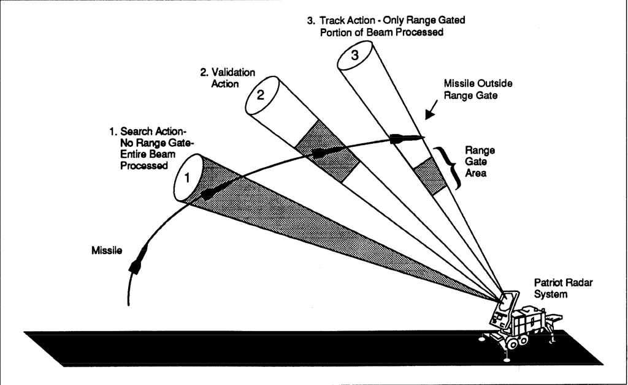

```python
Image(filename='./images/incorrect.png')
```

- To avoid detection it was designed to be mobile and operate for only a few hours at one location.
- Rebooting took about 60-90 seconds and reset the clock.
- Army officials assumed that users would not use the system longer than 8hours.

Reference https://www.gao.gov/products/IMTEC-92-26

## Variance

- Given a sequence of numbers $\{x\}_{i=1}^n$, variance is defined as

$ \frac{\sum_{i=1}^n (x_i - \bar{x})^2}{n} $, where $\bar{x}$ is the mean of $\{x\}_{i=1}^n$

- Easy two pass algorithm
  - Compute mean in the first pass
  - Use above formula to compute variance

```python
uniform = np.random.rand(1_000)
```

```python
def two_pass_var(seq):
    mean = sum(seq)/len(seq)
    return sum((x-mean)**2 for x in seq)/len(seq)

two_pass_var(uniform), 1/12
```

```
(0.08652602786723883, 0.08333333333333333)
```

What if dataset is too large and memory is limited?

- Or you have a stream of data?

Above formula can be easily massaged to derive formula below,

$$ \frac{\sum_{i=1}^n (x_i - \bar{x})^2}{n} \\ = \frac{\sum_{i=1}^n (x_i^2 - 2 x_i \bar{x} + \bar{x}^2)}{n} \\ = \frac{(\sum_{i=1}^n x_i^2) - 2 n \bar{x}^2 + n \bar{x}^2}{n} \\ = \frac{(\sum_{i=1}^n x_i^2) - \frac{ (\sum_{i=1}^n x_i)^2}{n}}{n} \\ $$

```python
def one_pass_var(seq):
    s = s2 = n = 0
    for x in seq:
        s += x
        s2 += x**2
        n += 1

    return (s2 - s**2/n)/n
one_pass_var(uniform)
```

```
0.08652602786723969
```

```python
shifts = list(range(1, 16))
two_pass = [two_pass_var(uniform + 10**shift) for shift in shifts]
one_pass = [one_pass_var(uniform + 10**shift) for shift in shifts]
with_np = [np.var(uniform + 10**shift) for shift in shifts]
df = pd.DataFrame({'shift': shifts, 'one_pass': one_pass, 'two_pass': two_pass, 'numpy': with_np})
```

```python
df.set_index('shift')
```

| shift | one_pass | two_pass | numpy |
| --- | --- | --- | --- |
| 1 | 8.652603e-02 | 0.086526 | 0.086526 |
| 2 | 8.652603e-02 | 0.086526 | 0.086526 |
| 3 | 8.652603e-02 | 0.086526 | 0.086526 |
| 4 | 8.652591e-02 | 0.086526 | 0.086526 |
| 5 | 8.650391e-02 | 0.086526 | 0.086526 |
| 6 | 8.800000e-02 | 0.086526 | 0.086526 |
| 7 | 3.200000e-02 | 0.086526 | 0.086526 |
| 8 | 1.024000e+01 | 0.086526 | 0.086526 |
| 9 | 9.175040e+02 | 0.086526 | 0.086526 |
| 10 | -6.710886e+04 | 0.086526 | 0.086526 |
| 11 | -3.435974e+07 | 0.086526 | 0.086526 |
| 12 | 6.871948e+08 | 0.086528 | 0.086527 |
| 13 | 1.424967e+12 | 0.089407 | 0.086517 |
| 14 | -5.516910e+13 | 0.301819 | 0.086560 |
| 15 | -2.147316e+16 | 0.250156 | 0.165344 |

## My Experience

Input Code:

```
x = 1;
p1 = 160481183;
p2 = 179424673;
for i = 1:5
   x = mod(x*(p1+1) + p1, p2);
   printf("%d\n", mod(x, 100));
end
```

Output:

```
94
60
76
92
95
```

```python
# Octave seq is: 94, 60, 76, 92, 95
x = 1
p1 = 160481183
p2 = 179424673

for i in range(1, 6):
    x = (x*(p1+1)+p1) % p2
    print(x%100)
```

```
94
58
78
70
31
```

```python
p2 * (p1+1) + p1 < 2**60
# This calculation can be done in 64bit (np.int64) bit arithmatic
```

```
True
```

```python
x = 141537694  # state after first number has been generated
print(x*(p1+1)+p1)
print(Decimal(float(x)*(p1+1)+p1))
```

```
22714136874230879
22714136874230880
```

```python
((float(x)*(p1+1)+p1) - (x*(p1+1)+p1))
```

```
0.0
```

```python
(float(x)*(p1+1)+p1) - float(x*(p1+1)+p1)
```

```
0.0
```

```python
print(np.finfo(np.float64))
# Notice the precision
```

```
Machine parameters for float64
---------------------------------------------------------------
precision =  15   resolution = 1.0000000000000001e-15
machep =    -52   eps =        2.2204460492503131e-16
negep =     -53   epsneg =     1.1102230246251565e-16
minexp =  -1022   tiny =       2.2250738585072014e-308
maxexp =   1024   max =        1.7976931348623157e+308
nexp =       11   min =        -max
---------------------------------------------------------------
```

```python
np.log10(2**53 - 1)
```

```
15.954589770191003
```

```python
p2 * (p1+1) + p1 < 2**53
```

```
False
```

```python
len('22714136874230879')
```

```
17
```

```python
# Octave seq is: 94, 60, 76, 92, 95
x = 1.0
for i in range(1, 6):
    x = (x*(p1+1)+p1) % p2
    print(x%100)
```

```
94.0
59.0
63.0
75.0
12.0
```

> Computes the remainder complementary to the floor_divide function. It is equivalent to the Python modulus operator`x1 % x2` and has the same sign as the divisor x2. The MATLAB function equivalent to `np.remainder` is `mod`.

```python
x = 1.0
for i in range(1, 6):
    x = np.remainder(x*(p1+1)+p1, p2)
    print (x%100)
```

```
94.0
59.0
63.0
75.0
12.0
```

So that was a lie!

### So, What is happening?

> The floor division and modulo operators are connected by the following identity: $a == (a//b)*b + (a\%b)$.

> - [Python documentation](https://docs.python.org/3.9/reference/expressions.html#binary-arithmetic-operations)

Does that mean, $ a\%b == a - (a//b)*b $?

```python
x = 141537694.0
a = (x * (p1 + 1) + p1)
b = p2
```

```python
q, r = a//b, a%b
q, r
```

```
(126594277.0, 119834459.0)
```

```python
a == q*b + r
```

```
True
```

```python
a - q*b == r  # I've been trying to figure this out, do not know why this happens!
```

```
False
```

```python
# Octave seq is: 94, 60, 76, 92, 95
def mod(x, y):
    z = math.floor(x/y)
    return x - y*z
```

```python
x = 1.
for i in range(1, 6):
    x = mod(x*(p1+1)+p1, p2)
    print(int(x)%100)
```

```
94
60
76
92
95
```

## Why did `two_pass_var` fail?

```python
u = uniform + 10**12
print(Decimal(np.sum(u)))
print(Decimal(sum(u)))
```

```
1000000000000526.375
1000000000000525.5
```

$a= 10000.0, \\ b = 3.14159, \\ c = 2.71828$

$a+b+c = 10005.85987$

Assume we have precision of 6 digits, then

$a+b+c = 10005.9$

$ \alpha = a+b= \text{round}(10003.14159) = 10003.1$

$ \alpha + c = \text{round}(10005.81828) = 10005.8$

$ \beta = b + c= \text{round}(5.85987) $ (Note that our pricision is 6)

$ \beta + a = \text{round}(10005.85987) = 10005.9$

- Naive summation (e.g. Python sum) error in worst case could be $\mathcal{O}(n \epsilon)$
  - Where $\epsilon$ is machine epsilon. For float64 $\approx 10^{-16}$
- Better algorithms like [Kahan's algorithm](https://en.wikipedia.org/wiki/Kahan_summation) has worst case error of $\mathcal{O}(\epsilon)$
- NumPy uses [Pairwise summation](https://en.wikipedia.org/wiki/Pairwise_summation), which has worst case error $\mathcal{O}(\epsilon log n)$

```python
def pairwise_sum(seq, i=0, j=None):
    if j is None: j = len(seq)-1
    if (j-i) <= 4:
        return sum(seq[i:j+1])
    k = i+(j-i)//2
    return pairwise_sum(seq, i, k) + pairwise_sum(seq, k+1, j)
```

```python
def two_pass_var_v2(seq, sum_fn):
    mean = sum_fn(seq)/len(seq)
    return sum_fn([(x-mean)**2 for x in seq])/len(seq)

u = uniform + 10**13
two_pass_var(u), two_pass_var_v2(u, pairwise_sum), np.var(u)
```

```
(0.0894066390991211, 0.0865167465209961, 0.0865167465209961)
```

### Kahan's Algorithm

```python
def kahan_sum(seq):        # Python implementation for algo from Wikipedia
    s = 0.0                # Prepare the accumulator.
    c = 0.0                # A running compensation for lost low-order bits.
    for elem in seq:
        y = elem - c       # c is zero the first time around.
        t = s + y          # Alas, s is big, y small, so low-order digits of y are lost.
        c = (t - s) - y    # (t - s) cancels the high-order part of y;
                           #    subtracting y recovers negative (low part of y)
        s = t              # Algebraically, c should always be zero.
                           # Next time around, the lost low part will be
                           # added to y in a fresh attempt.
    return s
```

```python
u = uniform + 10**15
np.var(u), two_pass_var_v2(u, kahan_sum), two_pass_var_v2(u, math.fsum)
```

```
(0.16534375, 0.08946875, 0.08946875)
```

```python
def one_pass_var_v2(seq, sum_fn):
    """This is non "streamable" version, but can be modified if `sum_fn`is "streamable"."""
    s = sum_fn(seq)
    s2 = sum_fn([x**2 for x in seq])
    n = len(seq)
    return (s2 - s**2/n)/n
```

```python
two_pass = [two_pass_var_v2(uniform + 10**shift, kahan_sum) for shift in shifts]
one_pass_v1 = [one_pass_var_v2(uniform + 10**shift, sum) for shift in shifts]
one_pass_v2 = [one_pass_var_v2(uniform + 10**shift, kahan_sum) for shift in shifts]
with_np = [np.var(uniform + 10**shift) for shift in shifts]
df = pd.DataFrame({'shift': shifts, 'one_pass_v1': one_pass_v1, 'one_pass_v2': one_pass_v2, 'two_pass': two_pass, 'numpy': with_np})
```

```python
df.set_index('shift')
```

| shift | one_pass_v1 | one_pass_v2 | two_pass | numpy |
| --- | --- | --- | --- | --- |
| 1 | 8.652603e-02 | 0.086526 | 0.086526 | 0.086526 |
| 2 | 8.652603e-02 | 0.086526 | 0.086526 | 0.086526 |
| 3 | 8.652603e-02 | 0.086526 | 0.086526 | 0.086526 |
| 4 | 8.652591e-02 | 0.086526 | 0.086526 | 0.086526 |
| 5 | 8.650391e-02 | 0.086525 | 0.086526 | 0.086526 |
| 6 | 8.800000e-02 | 0.086750 | 0.086526 | 0.086526 |
| 7 | 3.200000e-02 | 0.064000 | 0.086526 | 0.086526 |
| 8 | 1.024000e+01 | -2.048000 | 0.086526 | 0.086526 |
| 9 | 9.175040e+02 | 131.072000 | 0.086526 | 0.086526 |
| 10 | -6.710886e+04 | 0.000000 | 0.086526 | 0.086526 |
| 11 | -3.435974e+07 | 0.000000 | 0.086526 | 0.086526 |
| 12 | 6.871948e+08 | 0.000000 | 0.086527 | 0.086527 |
| 13 | 1.424967e+12 | 0.000000 | 0.086517 | 0.086517 |
| 14 | -5.516910e+13 | 0.000000 | 0.086560 | 0.086560 |
| 15 | -2.147316e+16 | 0.000000 | 0.089469 | 0.165344 |

## Catastrophic Cancellation

```python
uniform_d = [Decimal(x) for x in uniform]
```

Remember, in naive one pass algorithm, we had,

$ (\sum_{i=1}^n x_i^2) - \frac{ (\sum_{i=1}^n x_i)^2}{n} $

Let $a = \sum_{i=1}^n x_i^2 $

and $b = \frac{ (\sum_{i=1}^n x_i)^2}{n} $

```python
y = Decimal(1e7)
u = [x + y for x in uniform_d]
a = sum([x**2 for x in u])
b = sum(u)**2/len(u)

print(" a |  ", a, sep='')
print("-b | -", b, sep='')

print("a-b = ", a-b)
```

```
 a |  100000010528625719.1844890930
-b | -100000010528625632.6584612259
a-b =  86.5260278671
```

```python
u = [x + 1e7 for x in uniform]
a = math.fsum([x**2 for x in u])
b = math.fsum(u)**2/len(u)

print(" a |  ", Decimal(a), sep='')
print("-b | -", Decimal(b), sep='')

print("a-b = ", a-b)
```

```
 a |  100000010528625712
-b | -100000010528625648
a-b =  64.0
```

### While solvinig quadratic equation $a x^2 + b x + c = 0$

$ \frac{-b \pm \sqrt{b^2 - 4ac}}{2a} $, and $ b^2 \gg 4ac$

In the numerator, if $b \gt 0$, we have $-b + \sim b$.

How to avoid? [See Wikipedia](https://en.wikipedia.org/wiki/Loss_of_significance)

### Numerical Derivative

$ f'(x) = \lim_{h \to 0} \frac{f(x+h) - f(x)}{h} $

If you take $h$ very small, and $f$ is something that is not easy to compute (like $cos(x)$, or $\sqrt{x}$), this will again lead to catastrophic cancellation.

## Welford’s method for computing variance

Let $S_{n} = \frac{\Sigma_{i=1}^{n} (x_i - \bar{x_n})^2}{n} $

Theorem: $n S_n - (n-1) S_{n-1} = (x_n - \bar{x}_n) (x_n - \bar{x}_{n-1}) $

Proof:

$ n S_n - (n-1) S_{n-1} = \Sigma_{i=1}^n (x_i - \bar{x_n})^2 - \Sigma_{i=1}^{n-1} (x_i - \bar{x}_{n-1})^2 $

$ = \Sigma_{i=1}^{n-1}(x_i - \bar{x_n})^2 - \Sigma_{i=1}^{n-1} (x_i - \bar{x}_{n-1})^2 + (x_n - \bar{x}_n)^2 $

$ = \Sigma_{i=1}^{n-1} (x_i - \bar{x}_n - x_i + \bar{x}_{n-1}) (x_i - \bar{x}_n + x_i - \bar{x}_{n-1}) + (x_n - \bar{x}_n)^2 $

Because $ a^2 - b^2 = (a-b)(a+b)$

$ = (\bar{x}_{n-1} - \bar{x}_n) [ \Sigma_{i=1}^{n-1} (x_i - \bar{x}_n + x_i - \bar{x}_{n-1}) ]+ (x_n - \bar{x}_n)^2 $

$ = (\bar{x}_{n-1} - \bar{x}_n) [ \Sigma_{i=1}^{n-1} (x_i - \bar{x}_n) + \Sigma_{i=1}^{n-1}(x_i - \bar{x}_{n-1}) ]+ (x_n - \bar{x}_n)^2 $

$ = (\bar{x}_{n-1} - \bar{x}_n) [ \Sigma_{i=1}^{n-1} (x_i - \bar{x}_n)]+ (x_n - \bar{x}_n)^2 $

$ = (\bar{x}_{n-1} - \bar{x}_n) [ \Sigma_{i=1}^{n-1} (x_i - \bar{x}_n) + (x_n - \bar{x}_n) - (x_n - \bar{x}_n)]+ (x_n - \bar{x}_n)^2 $

$ = -(\bar{x}_{n-1} - \bar{x}_n)(x_n - \bar{x}_n)+ (x_n - \bar{x}_n)^2 $

$ = (x_n - \bar{x}_n) ( x_n - \bar{x}_n - \bar{x}_{n-1} + \bar{x}_n ) $

$ = (x_n - \bar{x}_n) (x_n - \bar{x}_{n-1}) $

It gives a recursive formulation to compute variance

$n S_n = (n-1) S_{n-1} + (x_n - \bar{x}_n) (x_n - \bar{x}_{n-1}) $

```python
def welford(seq):
    s = Kahan()
    mean = Kahan()

    for n, elem in enumerate(seq, 1):
        old_mean = mean.sum
        mean += (elem - mean.sum)/n
        s += (elem - old_mean)*(elem-mean.sum)

    return s.sum/n
```

```python
shifts = list(range(1, 16))
two_pass = [two_pass_var_v2(uniform + 10**shift, kahan_sum) for shift in shifts]
one_pass = [welford(uniform + 10**shift) for shift in shifts]
df = pd.DataFrame({'shift': shifts, 'welford': one_pass, 'two_pass': two_pass}).set_index('shift')
df
```

| shift | welford | two_pass |
| --- | --- | --- |
| 1 | 0.086526 | 0.086526 |
| 2 | 0.086526 | 0.086526 |
| 3 | 0.086526 | 0.086526 |
| 4 | 0.086526 | 0.086526 |
| 5 | 0.086526 | 0.086526 |
| 6 | 0.086526 | 0.086526 |
| 7 | 0.086526 | 0.086526 |
| 8 | 0.086526 | 0.086526 |
| 9 | 0.086526 | 0.086526 |
| 10 | 0.086526 | 0.086526 |
| 11 | 0.086525 | 0.086526 |
| 12 | 0.086518 | 0.086527 |
| 13 | 0.086418 | 0.086517 |
| 14 | 0.086522 | 0.086560 |
| 15 | 0.098359 | 0.089469 |